# SummaryPlot

Xiang Ji

December 29, 2014

This R script is used for generating summary plot for the Geneconv project

1, Read in tables

```r
rm(list=ls())  # clean up workspace
#path <- "/Users/xji3/Genconv/NewClusterPackRun/NewPackageNewRun/OldResults01152015/"
path <- "/Users/xji3/Genconv/NewClusterPackRun/NewPackageNewRun/"
#path <- "G:/Geneconv/NewClusterPackRun/NewPackageNewRun/"
#HKY_clock_summary <- "HKY_clock_summary"
summary.list <- c( "HKY_nonclock_summary",
                  "HKY_clock_summary",
                  "MG94_clock_summary",
                  "MG94_nonclock_summary",
                  "Force_HKY_clock_summary",
                  "Force_MG94_clock_summary",
                  "Force_MG94_nonclock_summary",
                 "Force_HKY_nonclock_summary"
                  )
#summary.list <- c("Force_MG94_clock_summary")
for (target.summary in summary.list){
  summary_file <- paste(path, target.summary, '.txt', sep = '')
  all <- readLines(summary_file, n = -1)
  col.names <- strsplit(all[1], ' ')[[1]][-1]
  row.names <- strsplit(all[length(all)], ' ')[[1]][-1]
  summary_mat <- as.matrix(read.table(summary_file,
                                        row.names = row.names,
                                        col.names = col.names))
  assign(target.summary, summary_mat)
}
```

Now generate summary file of only pairs that have all cases finished in HKY or MG94 models.

```r
# HKY
HKY.pair.names <- intersect(intersect(intersect(colnames(HKY_clock_summary),
                            colnames(HKY_nonclock_summary)),
                            colnames(Force_HKY_clock_summary)),
                            colnames(Force_HKY_nonclock_summary))
HKY.clock.filtered <- HKY_clock_summary[, HKY.pair.names]
HKY.nonclock.filtered <- HKY_nonclock_summary[, HKY.pair.names]
HKY.Force.clock.filtered <- Force_HKY_clock_summary[, HKY.pair.names]
HKY.Force.nonclock.filtered <- Force_HKY_nonclock_summary[, HKY.pair.names]

write.table(HKY.clock.filtered, paste( path, "HKY_clock_filtered", sep = ""))
write.table(HKY.nonclock.filtered, paste( path, "HKY_nonclock_filtered", sep = ""))
write.table(HKY.Force.clock.filtered, paste( path, "HKY_Force_clock_filtered", sep = ""))
write.table(HKY.Force.nonclock.filtered, paste( path, "HKY_Force_nonclock_filtered", sep = ""))



# MG94
MG94.pair.names <- intersect(intersect(intersect(colnames(MG94_clock_summary),
                            colnames(MG94_nonclock_summary)),
                            colnames(Force_MG94_clock_summary)),
                            colnames(Force_MG94_nonclock_summary))
MG94.clock.filtered <- MG94_clock_summary[, MG94.pair.names]
MG94.nonclock.filtered <- MG94_nonclock_summary[, MG94.pair.names]
MG94.Force.clock.filtered <- Force_MG94_clock_summary[, MG94.pair.names]
MG94.Force.nonclock.filtered <- Force_MG94_nonclock_summary[, MG94.pair.names]

write.table(MG94.clock.filtered, paste( path, "MG94_clock_filtered", sep = ""))
write.table(MG94.nonclock.filtered, paste( path, "MG94_nonclock_filtered", sep = ""))
write.table(MG94.Force.clock.filtered, paste( path, "MG94_Force_clock_filtered", sep = ""))
write.table(MG94.Force.nonclock.filtered, paste( path, "MG94_Force_nonclock_filtered", sep = ""))
```

Now analyze the results

First, show the loglikelihood improvement for each model with/without tau

```r
# HKY nonclock
(HKY.nonclock.filtered - HKY.Force.nonclock.filtered)[2,]
```

```
## YLR406C_YDL075W YER131W_YGL189C YDR502C_YLR180W YML026C_YDR450W
##           45.32           84.73          361.25          135.89
## YNL301C_YOL120C YHR106W_YDR353W YIL057C_YER067W YPL087W_YBR183W
##          152.26          165.28           42.03           46.49
## YNL069C_YIL133C YDR518W_YCL043C YGR043C_YLR354C YPR157W_YGR141W
##           90.04           42.93           60.11           73.59
## YDR099W_YER177W YBR024W_YBR037C YPL037C_YDR252W YMR143W_YDL083C
##          156.46           44.68           13.36           94.14
## YPR159W_YGR143W YJL177W_YKL180W YGL133W_YPL216W YJR048W_YEL039C
##          230.93           89.89           27.77           74.34
## YBR191W_YPL079W YER074W_YIL069C YDR418W_YEL054C YNL049C_YIL109C
##          120.41          155.79           96.07          158.20
## YBR117C_YPR074C YPL232W_YMR183C YLR284C_YOR180C YBL087C_YER117W
##           96.69          109.92           16.80          114.89
## YGL062W_YBR218C YIR033W_YKL020C YMR243C_YOR316C YLR333C_YGR027C
##         2313.16           94.99           85.48          108.80
## YMR142C_YDL082W YER102W_YBL072C YAL056W_YOR371C YDR438W_YML018C
##          325.89          232.13           22.94           17.39
```

```r
# HKY clock
(HKY.clock.filtered - HKY.Force.clock.filtered)[2,]
```

```
## YLR406C_YDL075W YER131W_YGL189C YDR502C_YLR180W YML026C_YDR450W
##          45.671          47.253         169.574         135.283
## YNL301C_YOL120C YHR106W_YDR353W YIL057C_YER067W YPL087W_YBR183W
##         149.475         145.207          41.107          39.588
## YNL069C_YIL133C YDR518W_YCL043C YGR043C_YLR354C YPR157W_YGR141W
##          77.690          34.149          40.567          63.727
## YDR099W_YER177W YBR024W_YBR037C YPL037C_YDR252W YMR143W_YDL083C
##         152.259          32.103          15.203          94.121
## YPR159W_YGR143W YJL177W_YKL180W YGL133W_YPL216W YJR048W_YEL039C
##         231.875          92.031          11.503          74.361
## YBR191W_YPL079W YER074W_YIL069C YDR418W_YEL054C YNL049C_YIL109C
##         119.181         163.762          93.715         121.540
## YBR117C_YPR074C YPL232W_YMR183C YLR284C_YOR180C YBL087C_YER117W
##          75.862          92.364          17.778         113.481
## YGL062W_YBR218C YIR033W_YKL020C YMR243C_YOR316C YLR333C_YGR027C
##        1262.228          76.723          66.710         118.885
## YMR142C_YDL082W YER102W_YBL072C YAL056W_YOR371C YDR438W_YML018C
##         201.923         229.128          26.628           7.088
```

```r
# # MG94 nonclock
(MG94.nonclock.filtered - MG94.Force.nonclock.filtered)[2,]
```

```
## YLR406C_YDL075W YER131W_YGL189C YDR502C_YLR180W YML026C_YDR450W
##         16.9829         15.6925         45.7337         67.0663
## YNL301C_YOL120C YHR106W_YDR353W YIL057C_YER067W YPL087W_YBR183W
##         75.7626         22.2515         16.4041         11.8007
## YNL069C_YIL133C YDR518W_YCL043C YGR043C_YLR354C YPR157W_YGR141W
##         58.6072         33.7745          5.5141          3.0304
## YDR099W_YER177W YBR024W_YBR037C YPL037C_YDR252W YMR143W_YDL083C
##         14.2550          8.0704          3.7651         37.2294
## YPR159W_YGR143W YJL177W_YKL180W YGL133W_YPL216W YJR048W_YEL039C
##         54.5433         36.6197          5.4345         21.5963
## YBR191W_YPL079W YER074W_YIL069C YDR418W_YEL054C YNL049C_YIL109C
##         66.1023        109.5897         32.0401         52.5654
## YBR117C_YPR074C YPL232W_YMR183C YLR284C_YOR180C YBL087C_YER117W
##         18.3337         30.0242          0.8921         47.6112
## YGL062W_YBR218C YIR033W_YKL020C YMR243C_YOR316C YLR333C_YGR027C
##        442.2758         30.9332          7.5214         83.6476
## YMR142C_YDL082W YER102W_YBL072C YAL056W_YOR371C YDR438W_YML018C
##        142.9763        137.7021         14.6466          3.2045
```

```r
# # MG94 clock
(MG94.clock.filtered - MG94.Force.clock.filtered)[2,]
```

```
## YLR406C_YDL075W YER131W_YGL189C YDR502C_YLR180W YML026C_YDR450W
##         17.4243         15.5316         39.4858         68.2585
## YNL301C_YOL120C YHR106W_YDR353W YIL057C_YER067W YPL087W_YBR183W
##         79.5599         20.3225         16.7182         11.3831
## YNL069C_YIL133C YDR518W_YCL043C YGR043C_YLR354C YPR157W_YGR141W
##         53.3016         30.6935          3.1881          3.4421
## YDR099W_YER177W YBR024W_YBR037C YPL037C_YDR252W YMR143W_YDL083C
##         15.7527          6.6699          6.0741         38.8762
## YPR159W_YGR143W YJL177W_YKL180W YGL133W_YPL216W YJR048W_YEL039C
##         57.5931         38.7124          1.8099         23.4107
## YBR191W_YPL079W YER074W_YIL069C YDR418W_YEL054C YNL049C_YIL109C
##         66.8738        117.9944         30.5241         48.0554
## YBR117C_YPR074C YPL232W_YMR183C YLR284C_YOR180C YBL087C_YER117W
##         13.5554         28.8624          0.8199         49.5502
## YGL062W_YBR218C YIR033W_YKL020C YMR243C_YOR316C YLR333C_YGR027C
##        480.0590         25.3488          5.3776         92.3176
## YMR142C_YDL082W YER102W_YBL072C YAL056W_YOR371C YDR438W_YML018C
##        146.3872        140.9595         18.1781          0.6008
```

Then, show the edge specific tau estimates (posterior expected number of geneconv events / posterior expected time in heterogeneous states of each branch)

```r
HKY.nonclock.filtered[21:32, ]
```

```
##                       YLR406C_YDL075W YER131W_YGL189C YDR502C_YLR180W
## (N0,N1,tau)                     8.023           7.160           2.942
## (N0,kluyveri,tau)               0.000           0.000           0.000
## (N1,N2,tau)                    10.020           8.121           3.116
## (N1,castellii,tau)              9.965           7.194           3.169
## (N2,N3,tau)                     5.499           8.104           2.830
## (N2,bayanus,tau)                8.309           8.056           3.168
## (N3,N4,tau)                     5.516           6.568           3.247
## (N3,kudriavzevii,tau)           4.164           7.661           3.552
## (N4,N5,tau)                    12.586           6.631           3.241
## (N4,mikatae,tau)                7.694           8.282           3.046
## (N5,cerevisiae,tau)             6.505          11.615           3.405
## (N5,paradoxus,tau)              8.504           4.075           2.922
##                       YML026C_YDR450W YNL301C_YOL120C YHR106W_YDR353W
## (N0,N1,tau)                    14.083          10.587           1.801
## (N0,kluyveri,tau)               0.000           0.000           0.000
## (N1,N2,tau)                    13.742          10.202           1.573
## (N1,castellii,tau)             18.479          11.177           2.227
## (N2,N3,tau)                    15.164          11.786           1.652
## (N2,bayanus,tau)               17.002          14.138           1.820
## (N3,N4,tau)                     6.143           8.826           1.744
## (N3,kudriavzevii,tau)          15.503          10.149           1.682
## (N4,N5,tau)                    17.236          11.723           1.677
## (N4,mikatae,tau)               13.864           7.845           1.790
## (N5,cerevisiae,tau)            19.419          17.757           2.121
## (N5,paradoxus,tau)             16.333           6.927           1.707
##                       YIL057C_YER067W YPL087W_YBR183W YNL069C_YIL133C
## (N0,N1,tau)                    0.9864          0.4711           5.099
## (N0,kluyveri,tau)              0.0000          0.0000           0.000
## (N1,N2,tau)                    0.9380          0.4248           5.060
## (N1,castellii,tau)             1.1657          0.5067           6.307
## (N2,N3,tau)                    0.9198          0.3093           6.178
## (N2,bayanus,tau)               0.7903          0.4962           5.876
## (N3,N4,tau)                    0.7104          0.4495           6.453
## (N3,kudriavzevii,tau)          0.9511          0.4387           3.808
## (N4,N5,tau)                    0.6356          0.4750           4.843
## (N4,mikatae,tau)               1.1071          0.4834           3.037
## (N5,cerevisiae,tau)            0.7710          0.5487           4.258
## (N5,paradoxus,tau)             1.1633          0.4167           4.388
##                       YDR518W_YCL043C YGR043C_YLR354C YPR157W_YGR141W
```

[output cut: 101 more lines]

```
## (N5,cerevisiae,tau)            0.6755          10.144           9.302
## (N5,paradoxus,tau)             0.5867           5.495          17.771
##                       YER102W_YBL072C YAL056W_YOR371C YDR438W_YML018C
## (N0,N1,tau)                    13.838          0.1458          0.2116
## (N0,kluyveri,tau)               0.000          0.0000          0.0000
## (N1,N2,tau)                    15.688          0.1432          0.2221
## (N1,castellii,tau)             15.348          0.1411          0.2396
## (N2,N3,tau)                    16.279          0.1333          0.1775
## (N2,bayanus,tau)               19.523          0.1339          0.2196
## (N3,N4,tau)                    23.216          0.1438          0.1697
## (N3,kudriavzevii,tau)           9.835          0.1365          0.1661
## (N4,N5,tau)                    32.514          0.1559          0.1884
## (N4,mikatae,tau)               15.832          0.1474          0.1991
## (N5,cerevisiae,tau)            48.916          0.2037          0.1565
## (N5,paradoxus,tau)             23.212          0.1533          0.1921
```

Now plot Total blen v.s. Tau into different groups (differ by color)

HKY nonclock case

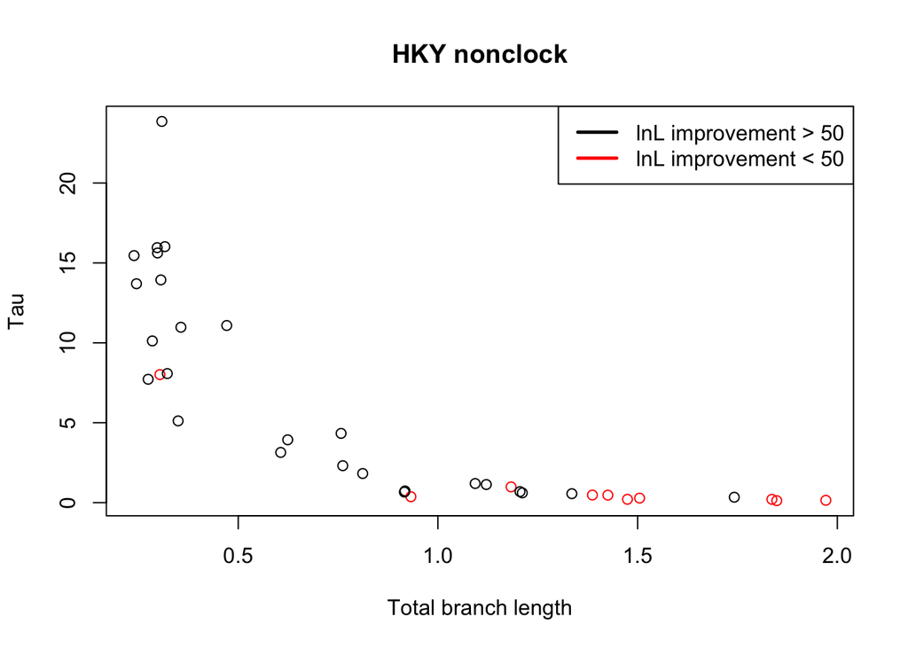

```r
plot(colSums(HKY.Force.nonclock.filtered[9:20, ]), HKY.nonclock.filtered[8, ],
     type = "n", xlab = "Total branch length", ylab = "Tau" )
col.color <- rep("black", dim(HKY.nonclock.filtered)[2])
col.color[(HKY.nonclock.filtered - HKY.Force.nonclock.filtered)[2,] < 50] <- "red"
points(x = colSums(HKY.Force.nonclock.filtered[9:20, ]), y = HKY.nonclock.filtered[8, ],
       type = "p", col = col.color, bg = col.color)
legend("topright", c("lnL improvement > 50", "lnL improvement < 50"),
       lty = c(1, 1),
       lwd = c(2.5, 2.5),
       col = c("black", "red"))
title("HKY nonclock")
```

HKY clock case

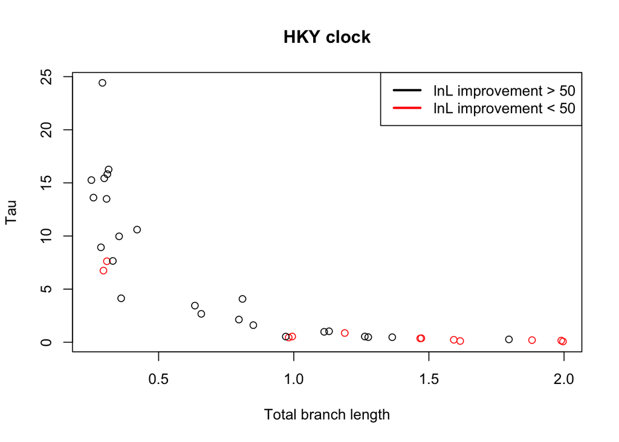

```r
plot(colSums(HKY.Force.clock.filtered[9:20, ]), HKY.clock.filtered[8, ],
     type = "n", xlab = "Total branch length", ylab = "Tau" )
col.color <- rep("black", dim(HKY.clock.filtered)[2])
col.color[(HKY.clock.filtered - HKY.Force.clock.filtered)[2,] < 50] <- "red"
points(x = colSums(HKY.Force.clock.filtered[9:20, ]), y = HKY.clock.filtered[8, ],
       type = "p", col = col.color, bg = col.color)
legend("topright", c("lnL improvement > 50", "lnL improvement < 50"),
       lty = c(1, 1),
       lwd = c(2.5, 2.5),
       col = c("black", "red"))
title("HKY clock")
```

MG94 nonclock case

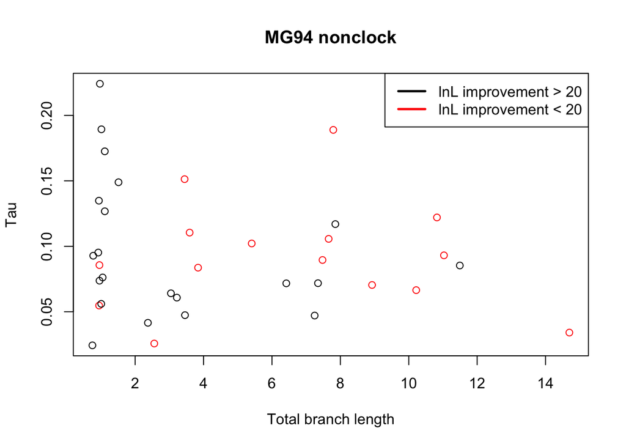

```r
improvement.lmt <- 20
plot(colSums(MG94.Force.nonclock.filtered[10:21, ]), MG94.nonclock.filtered[8, ],
     type = "n", xlab = "Total branch length", ylab = "Tau" )
col.color <- rep("black", dim(MG94.nonclock.filtered)[2])
col.color[(MG94.nonclock.filtered - MG94.Force.nonclock.filtered)[2,] < improvement.lmt] <- "red"
points(x = colSums(MG94.Force.nonclock.filtered[10:21, ]), y = MG94.nonclock.filtered[8, ],
       type = "p", col = col.color, bg = col.color)
legend("topright",
       c(paste("lnL improvement > ", toString(improvement.lmt), sep = ""),
         paste("lnL improvement < ", toString(improvement.lmt), sep = "")),
       lty = c(1, 1),
       lwd = c(2.5, 2.5),
       col = c("black", "red"))
title("MG94 nonclock")
```

MG94 clock case

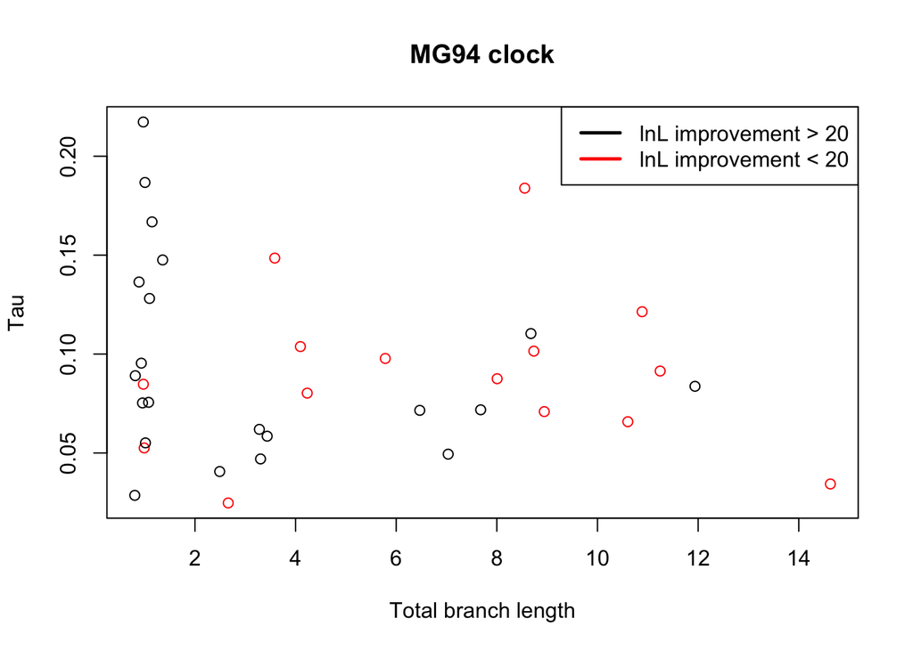

```r
improvement.lmt <- 20
plot(colSums(MG94.Force.clock.filtered[10:21, ]), MG94.clock.filtered[8, ],
     type = "n", xlab = "Total branch length", ylab = "Tau" )
col.color <- rep("black", dim(MG94.clock.filtered)[2])
col.color[(MG94.clock.filtered - MG94.Force.clock.filtered)[2,] < improvement.lmt] <- "red"
points(x = colSums(MG94.Force.clock.filtered[10:21, ]), y = MG94.clock.filtered[8, ],
       type = "p", col = col.color, bg = col.color)
legend("topright",
       c(paste("lnL improvement > ", toString(improvement.lmt), sep = ""),
         paste("lnL improvement < ", toString(improvement.lmt), sep = "")),
       lty = c(1, 1),
       lwd = c(2.5, 2.5),
       col = c("black", "red"))
title("MG94 clock")
```

Now see if the pairs red in HKY are also red in MG94

nonclock case

```r
HKY.pair.names[(HKY.nonclock.filtered - HKY.Force.nonclock.filtered)[2,] < 50]
```

```
##  [1] "YLR406C_YDL075W" "YIL057C_YER067W" "YPL087W_YBR183W"
##  [4] "YDR518W_YCL043C" "YBR024W_YBR037C" "YPL037C_YDR252W"
##  [7] "YGL133W_YPL216W" "YLR284C_YOR180C" "YAL056W_YOR371C"
## [10] "YDR438W_YML018C"
```

```r
MG94.pair.names[(MG94.nonclock.filtered - MG94.Force.nonclock.filtered)[2,] < improvement.lmt]
```

```
##  [1] "YLR406C_YDL075W" "YER131W_YGL189C" "YIL057C_YER067W"
##  [4] "YPL087W_YBR183W" "YGR043C_YLR354C" "YPR157W_YGR141W"
##  [7] "YDR099W_YER177W" "YBR024W_YBR037C" "YPL037C_YDR252W"
## [10] "YGL133W_YPL216W" "YBR117C_YPR074C" "YLR284C_YOR180C"
## [13] "YMR243C_YOR316C" "YAL056W_YOR371C" "YDR438W_YML018C"
```

clock case

```r
HKY.pair.names[(HKY.clock.filtered - HKY.Force.clock.filtered)[2,] < 50]
```

```
##  [1] "YLR406C_YDL075W" "YER131W_YGL189C" "YIL057C_YER067W"
##  [4] "YPL087W_YBR183W" "YDR518W_YCL043C" "YGR043C_YLR354C"
##  [7] "YBR024W_YBR037C" "YPL037C_YDR252W" "YGL133W_YPL216W"
## [10] "YLR284C_YOR180C" "YAL056W_YOR371C" "YDR438W_YML018C"
```

```r
MG94.pair.names[(MG94.clock.filtered - MG94.Force.clock.filtered)[2,] < improvement.lmt]
```

```
##  [1] "YLR406C_YDL075W" "YER131W_YGL189C" "YIL057C_YER067W"
##  [4] "YPL087W_YBR183W" "YGR043C_YLR354C" "YPR157W_YGR141W"
##  [7] "YDR099W_YER177W" "YBR024W_YBR037C" "YPL037C_YDR252W"
## [10] "YGL133W_YPL216W" "YBR117C_YPR074C" "YLR284C_YOR180C"
## [13] "YMR243C_YOR316C" "YAL056W_YOR371C" "YDR438W_YML018C"
```

=========================================

Now plot Total blen v.s. Tau into different groups (differ by lnL improvement per site)

HKY nonclock case

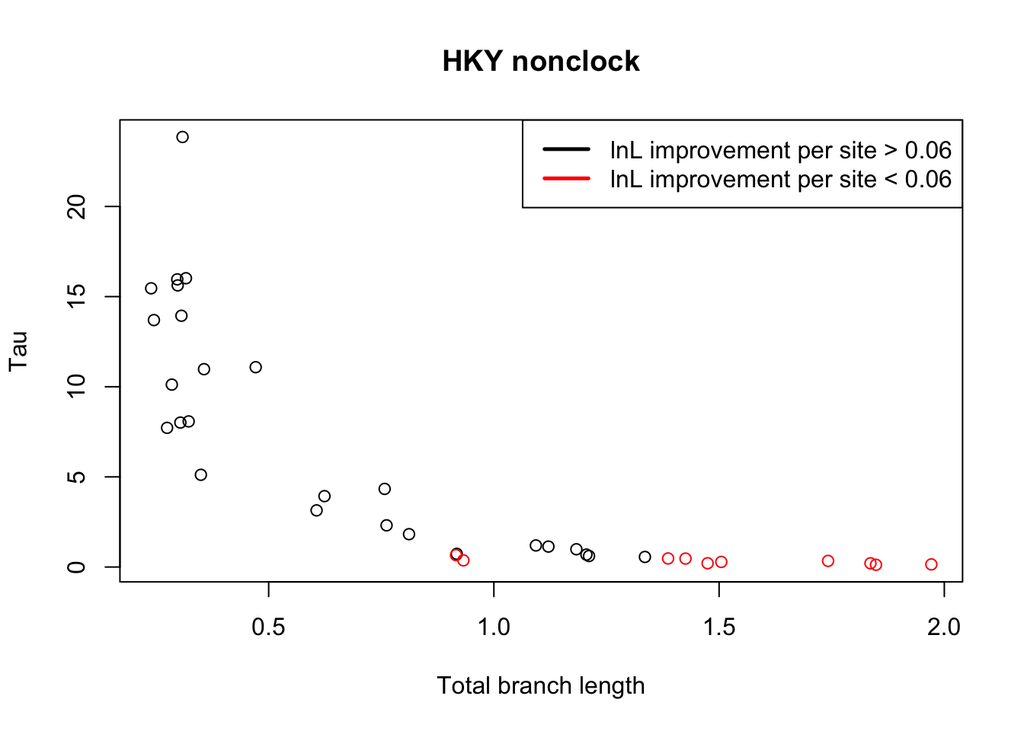

```r
plot(colSums(HKY.Force.nonclock.filtered[9:20, ]), HKY.nonclock.filtered[8, ],
     type = "n", xlab = "Total branch length", ylab = "Tau" )
col.color <- rep("black", dim(HKY.nonclock.filtered)[2])
col.color[((HKY.nonclock.filtered - HKY.Force.nonclock.filtered)[2,] /  HKY.nonclock.filtered[1, ]) < 0.06] <- "red"
points(x = colSums(HKY.Force.nonclock.filtered[9:20, ]), y = HKY.nonclock.filtered[8, ],
       type = "p", col = col.color, bg = col.color)
legend("topright", c("lnL improvement per site > 0.06",
                     "lnL improvement per site < 0.06"),
       lty = c(1, 1),
       lwd = c(2.5, 2.5),
       col = c("black", "red"))
title("HKY nonclock")
```

```r
# lnL improvement per site
((HKY.nonclock.filtered - HKY.Force.nonclock.filtered)[2,] /  HKY.nonclock.filtered[1, ])
```

```
## YLR406C_YDL075W YER131W_YGL189C YDR502C_YLR180W YML026C_YDR450W
##        0.134895        0.239360        0.316054        0.323549
## YNL301C_YOL120C YHR106W_YDR353W YIL057C_YER067W YPL087W_YBR183W
##        0.274350        0.173246        0.090389        0.050645
## YNL069C_YIL133C YDR518W_YCL043C YGR043C_YLR354C YPR157W_YGR141W
##        0.152353        0.028735        0.060532        0.060868
## YDR099W_YER177W YBR024W_YBR037C YPL037C_YDR252W YMR143W_YDL083C
##        0.210301        0.053765        0.031368        0.234189
## YPR159W_YGR143W YJL177W_YKL180W YGL133W_YPL216W YJR048W_YEL039C
##        0.115064        0.163738        0.009705        0.229431
## YBR191W_YPL079W YER074W_YIL069C YDR418W_YEL054C YNL049C_YIL109C
##        0.252429        0.390453        0.196469        0.063228
## YBR117C_YPR074C YPL232W_YMR183C YLR284C_YOR180C YBL087C_YER117W
##        0.047468        0.127221        0.020902        0.281591
## YGL062W_YBR218C YIR033W_YKL020C YMR243C_YOR316C YLR333C_YGR027C
##        0.682954        0.037829        0.076393        0.338941
## YMR142C_YDL082W YER102W_YBL072C YAL056W_YOR371C YDR438W_YML018C
##        0.551414        0.390796        0.011673        0.017508
```

HKY clock case

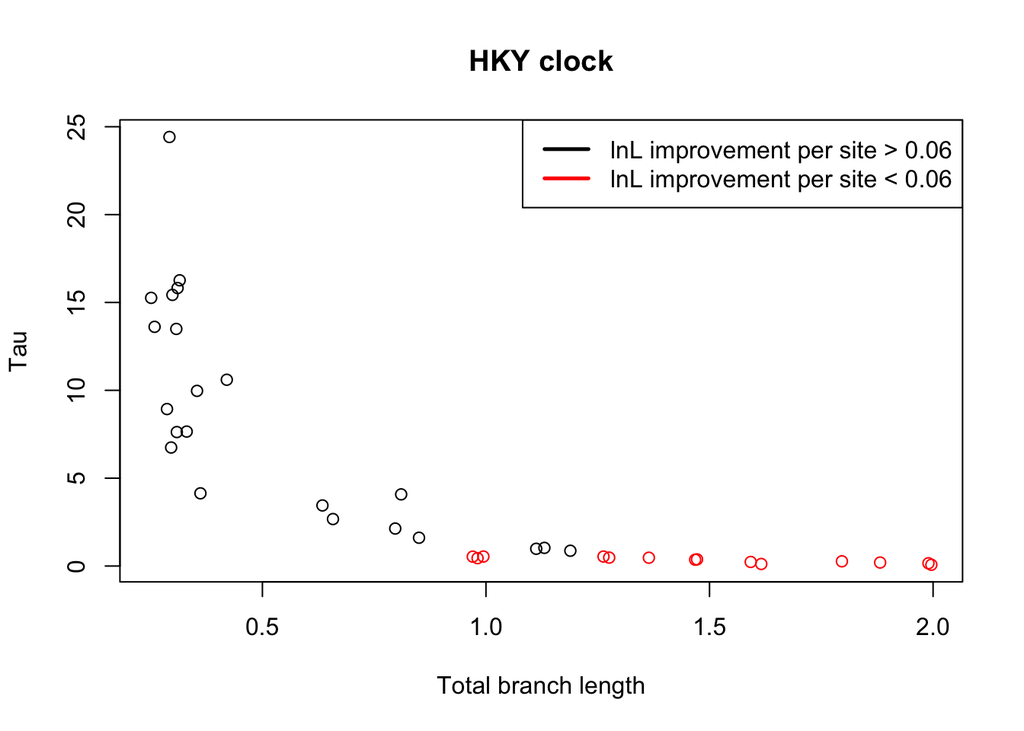

```r
plot(colSums(HKY.Force.clock.filtered[9:20, ]), HKY.clock.filtered[8, ],
     type = "n", xlab = "Total branch length", ylab = "Tau" )
col.color <- rep("black", dim(HKY.clock.filtered)[2])
col.color[((HKY.clock.filtered - HKY.Force.clock.filtered)[2,] /  HKY.clock.filtered[1, ]) < 0.06] <- "red"
points(x = colSums(HKY.Force.clock.filtered[9:20, ]), y = HKY.clock.filtered[8, ],
       type = "p", col = col.color, bg = col.color)
legend("topright", c("lnL improvement per site > 0.06",
                     "lnL improvement per site < 0.06"),
       lty = c(1, 1),
       lwd = c(2.5, 2.5),
       col = c("black", "red"))
title("HKY clock")
```

```r
# lnL improvement per site
((HKY.clock.filtered - HKY.Force.clock.filtered)[2,] /  HKY.clock.filtered[1, ])
```

```
## YLR406C_YDL075W YER131W_YGL189C YDR502C_YLR180W YML026C_YDR450W
##        0.135924        0.133484        0.148359        0.322104
## YNL301C_YOL120C YHR106W_YDR353W YIL057C_YER067W YPL087W_YBR183W
##        0.269324        0.152208        0.088402        0.043125
## YNL069C_YIL133C YDR518W_YCL043C YGR043C_YLR354C YPR157W_YGR141W
##        0.131456        0.022857        0.040853        0.052711
## YDR099W_YER177W YBR024W_YBR037C YPL037C_YDR252W YMR143W_YDL083C
##        0.204649        0.038632        0.035687        0.234132
## YPR159W_YGR143W YJL177W_YKL180W YGL133W_YPL216W YJR048W_YEL039C
##        0.115533        0.167633        0.004019        0.229508
## YBR191W_YPL079W YER074W_YIL069C YDR418W_YEL054C YNL049C_YIL109C
##        0.249856        0.410432        0.191646        0.048577
## YBR117C_YPR074C YPL232W_YMR183C YLR284C_YOR180C YBL087C_YER117W
##        0.037242        0.106903        0.022112        0.278139
## YGL062W_YBR218C YIR033W_YKL020C YMR243C_YOR316C YLR333C_YGR027C
##        0.372669        0.030555        0.059616        0.370357
## YMR142C_YDL082W YER102W_YBL072C YAL056W_YOR371C YDR438W_YML018C
##        0.341663        0.385737        0.013551        0.007138
```

MG94 nonclock case

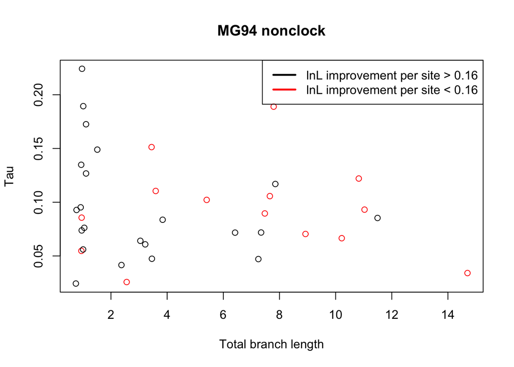

```r
improvement.lmt <- 0.16
plot(colSums(MG94.Force.nonclock.filtered[10:21, ]), MG94.nonclock.filtered[8, ],
     type = "n", xlab = "Total branch length", ylab = "Tau" )
col.color <- rep("black", dim(MG94.nonclock.filtered)[2])
col.color[((MG94.nonclock.filtered - MG94.Force.nonclock.filtered)[2,] / MG94.nonclock.filtered[1]) < improvement.lmt] <- "red"
points(x = colSums(MG94.Force.nonclock.filtered[10:21, ]), y = MG94.nonclock.filtered[8, ],
       type = "p", col = col.color, bg = col.color)
legend("topright",
       c(paste("lnL improvement per site > ", toString(improvement.lmt), sep = ""),
         paste("lnL improvement per site < ", toString(improvement.lmt), sep = "")),
       lty = c(1, 1),
       lwd = c(2.5, 2.5),
       col = c("black", "red"))
title("MG94 nonclock")
```

```r
# lnL improvement per site
((MG94.nonclock.filtered - MG94.Force.nonclock.filtered)[2,] / MG94.nonclock.filtered[1])
```

```
## YLR406C_YDL075W YER131W_YGL189C YDR502C_YLR180W YML026C_YDR450W
##        0.151633        0.140112        0.408336        0.598806
## YNL301C_YOL120C YHR106W_YDR353W YIL057C_YER067W YPL087W_YBR183W
##        0.676452        0.198674        0.146465        0.105364
## YNL069C_YIL133C YDR518W_YCL043C YGR043C_YLR354C YPR157W_YGR141W
##        0.523279        0.301558        0.049233        0.027057
## YDR099W_YER177W YBR024W_YBR037C YPL037C_YDR252W YMR143W_YDL083C
##        0.127277        0.072057        0.033617        0.332405
## YPR159W_YGR143W YJL177W_YKL180W YGL133W_YPL216W YJR048W_YEL039C
##        0.486994        0.326962        0.048523        0.192824
## YBR191W_YPL079W YER074W_YIL069C YDR418W_YEL054C YNL049C_YIL109C
##        0.590199        0.978479        0.286073        0.469334
## YBR117C_YPR074C YPL232W_YMR183C YLR284C_YOR180C YBL087C_YER117W
##        0.163693        0.268073        0.007965        0.425100
## YGL062W_YBR218C YIR033W_YKL020C YMR243C_YOR316C YLR333C_YGR027C
##        3.948891        0.276189        0.067155        0.746853
## YMR142C_YDL082W YER102W_YBL072C YAL056W_YOR371C YDR438W_YML018C
##        1.276574        1.229483        0.130773        0.028611
```

MG94 clock case

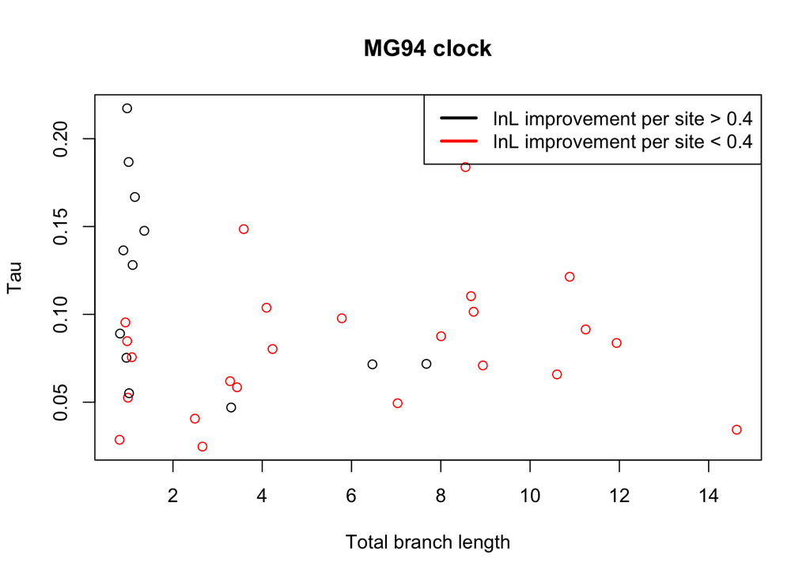

```r
improvement.lmt <- 0.4
plot(colSums(MG94.Force.clock.filtered[10:21, ]), MG94.clock.filtered[8, ],
     type = "n", xlab = "Total branch length", ylab = "Tau" )
col.color <- rep("black", dim(MG94.clock.filtered)[2])
col.color[((MG94.clock.filtered - MG94.Force.clock.filtered)[2,] / MG94.clock.filtered[1]) < improvement.lmt] <- "red"
points(x = colSums(MG94.Force.clock.filtered[10:21, ]), y = MG94.clock.filtered[8, ],
       type = "p", col = col.color, bg = col.color)
legend("topright",
       c(paste("lnL improvement per site > ", toString(improvement.lmt), sep = ""),
         paste("lnL improvement per site < ", toString(improvement.lmt), sep = "")),
       lty = c(1, 1),
       lwd = c(2.5, 2.5),
       col = c("black", "red"))
title("MG94 clock")
```

```r
# lnL improvement per site
((MG94.clock.filtered - MG94.Force.clock.filtered)[2,] / MG94.clock.filtered[1])
```

```
## YLR406C_YDL075W YER131W_YGL189C YDR502C_YLR180W YML026C_YDR450W
##        0.155574        0.138675        0.352552        0.609451
## YNL301C_YOL120C YHR106W_YDR353W YIL057C_YER067W YPL087W_YBR183W
##        0.710357        0.181451        0.149269        0.101635
## YNL069C_YIL133C YDR518W_YCL043C YGR043C_YLR354C YPR157W_YGR141W
##        0.475907        0.274049        0.028466        0.030733
## YDR099W_YER177W YBR024W_YBR037C YPL037C_YDR252W YMR143W_YDL083C
##        0.140649        0.059552        0.054233        0.347109
## YPR159W_YGR143W YJL177W_YKL180W YGL133W_YPL216W YJR048W_YEL039C
##        0.514224        0.345646        0.016160        0.209024
## YBR191W_YPL079W YER074W_YIL069C YDR418W_YEL054C YNL049C_YIL109C
##        0.597088        1.053521        0.272536        0.429066
## YBR117C_YPR074C YPL232W_YMR183C YLR284C_YOR180C YBL087C_YER117W
##        0.121030        0.257700        0.007321        0.442413
## YGL062W_YBR218C YIR033W_YKL020C YMR243C_YOR316C YLR333C_YGR027C
##        4.286241        0.226329        0.048014        0.824265
## YMR142C_YDL082W YER102W_YBL072C YAL056W_YOR371C YDR438W_YML018C
##        1.307028        1.258567        0.162304        0.005364
```

OK, the MG94 nonclock long branch lengths are suspecious. It seems that the first four branches carry most of the total length. What if plot without those branches?

MG94 nonclock case without first four branches: (N0, N1), (N0,kluyveri), (N1,N2), (N1,castellii) are excluded

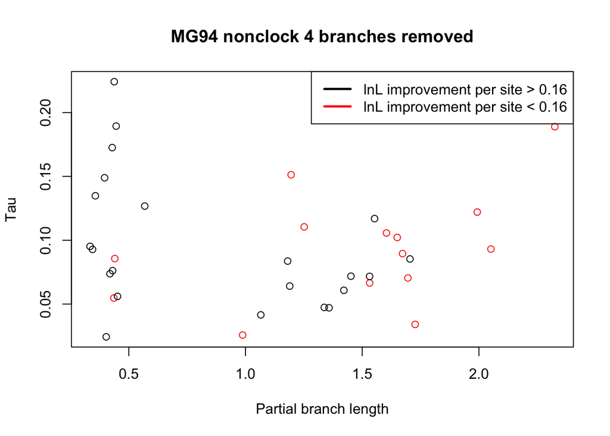

```r
improvement.lmt <- 0.16
plot(colSums(MG94.Force.nonclock.filtered[14:21, ]), MG94.nonclock.filtered[8, ],
     type = "n", xlab = "Partial branch length", ylab = "Tau" )
col.color <- rep("black", dim(MG94.nonclock.filtered)[2])
col.color[((MG94.nonclock.filtered - MG94.Force.nonclock.filtered)[2,] / MG94.nonclock.filtered[1]) < improvement.lmt] <- "red"
points(x = colSums(MG94.Force.nonclock.filtered[14:21, ]), y = MG94.nonclock.filtered[8, ],
       type = "p", col = col.color, bg = col.color)
legend("topright",
       c(paste("lnL improvement per site > ", toString(improvement.lmt), sep = ""),
         paste("lnL improvement per site < ", toString(improvement.lmt), sep = "")),
       lty = c(1, 1),
       lwd = c(2.5, 2.5),
       col = c("black", "red"))
title("MG94 nonclock 4 branches removed")
```

```r
# lnL improvement per site
((MG94.nonclock.filtered - MG94.Force.nonclock.filtered)[2,] / MG94.nonclock.filtered[1])
```

```
## YLR406C_YDL075W YER131W_YGL189C YDR502C_YLR180W YML026C_YDR450W
##        0.151633        0.140112        0.408336        0.598806
## YNL301C_YOL120C YHR106W_YDR353W YIL057C_YER067W YPL087W_YBR183W
##        0.676452        0.198674        0.146465        0.105364
## YNL069C_YIL133C YDR518W_YCL043C YGR043C_YLR354C YPR157W_YGR141W
##        0.523279        0.301558        0.049233        0.027057
## YDR099W_YER177W YBR024W_YBR037C YPL037C_YDR252W YMR143W_YDL083C
##        0.127277        0.072057        0.033617        0.332405
## YPR159W_YGR143W YJL177W_YKL180W YGL133W_YPL216W YJR048W_YEL039C
##        0.486994        0.326962        0.048523        0.192824
## YBR191W_YPL079W YER074W_YIL069C YDR418W_YEL054C YNL049C_YIL109C
##        0.590199        0.978479        0.286073        0.469334
## YBR117C_YPR074C YPL232W_YMR183C YLR284C_YOR180C YBL087C_YER117W
##        0.163693        0.268073        0.007965        0.425100
## YGL062W_YBR218C YIR033W_YKL020C YMR243C_YOR316C YLR333C_YGR027C
##        3.948891        0.276189        0.067155        0.746853
## YMR142C_YDL082W YER102W_YBL072C YAL056W_YOR371C YDR438W_YML018C
##        1.276574        1.229483        0.130773        0.028611
```

=========================================

Now, plot histogram of posterior expected Number of geneconv events from paralog 1 to paralog2 / paralog2 to paralog 1

HKY Non-clock

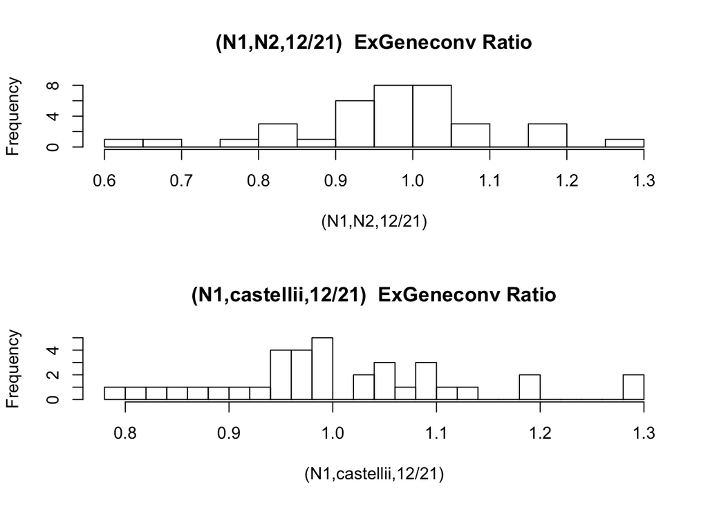

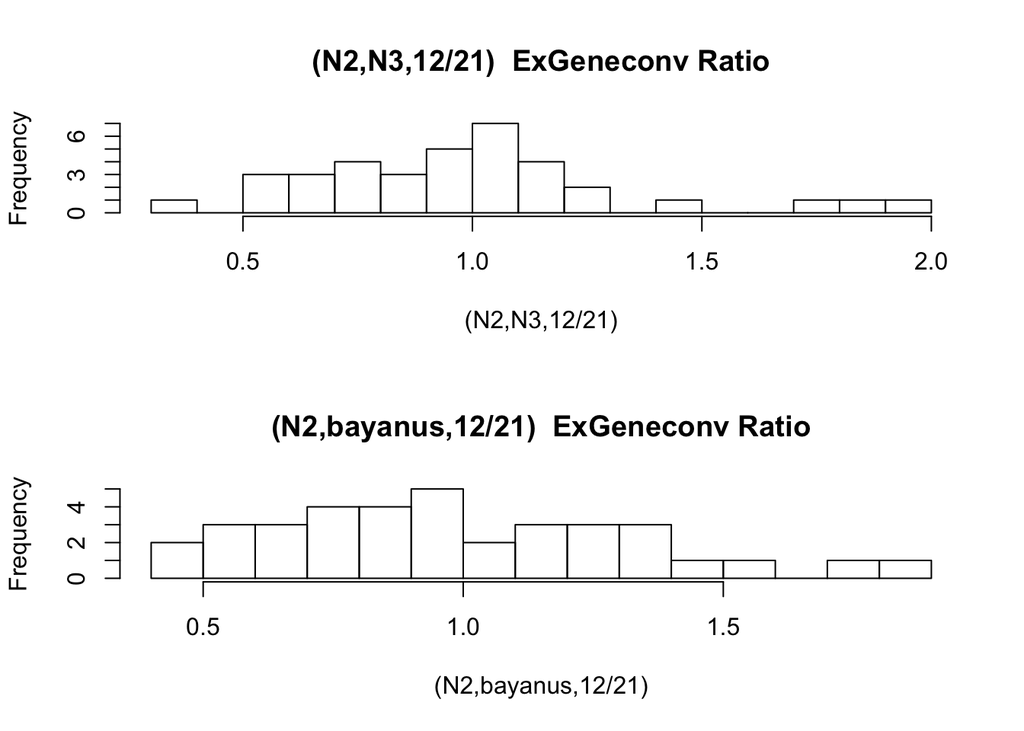

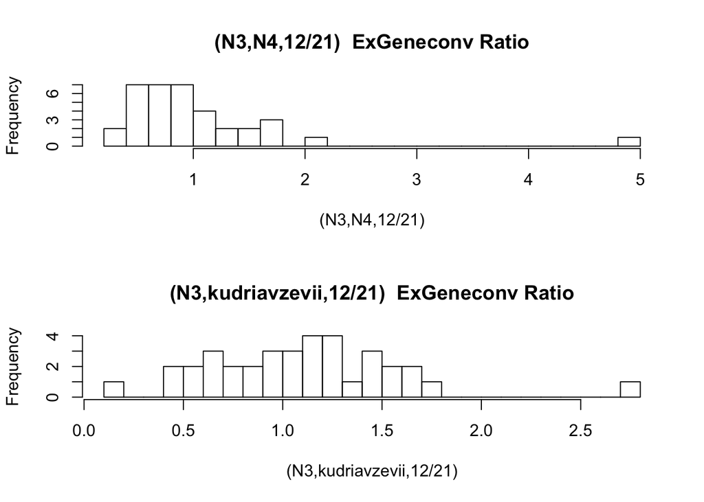

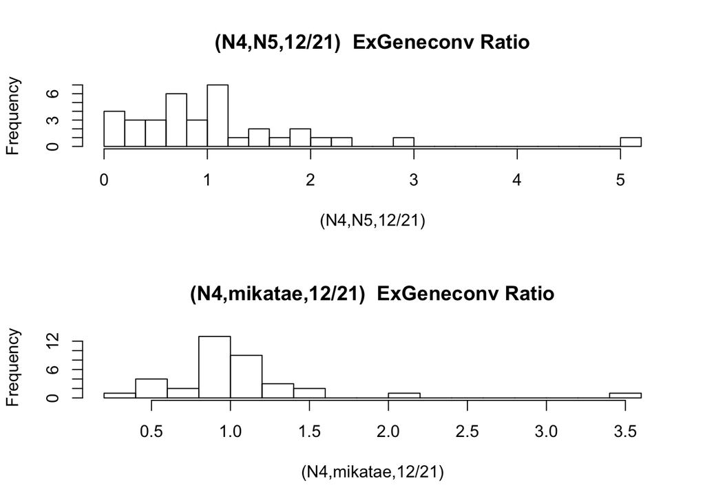

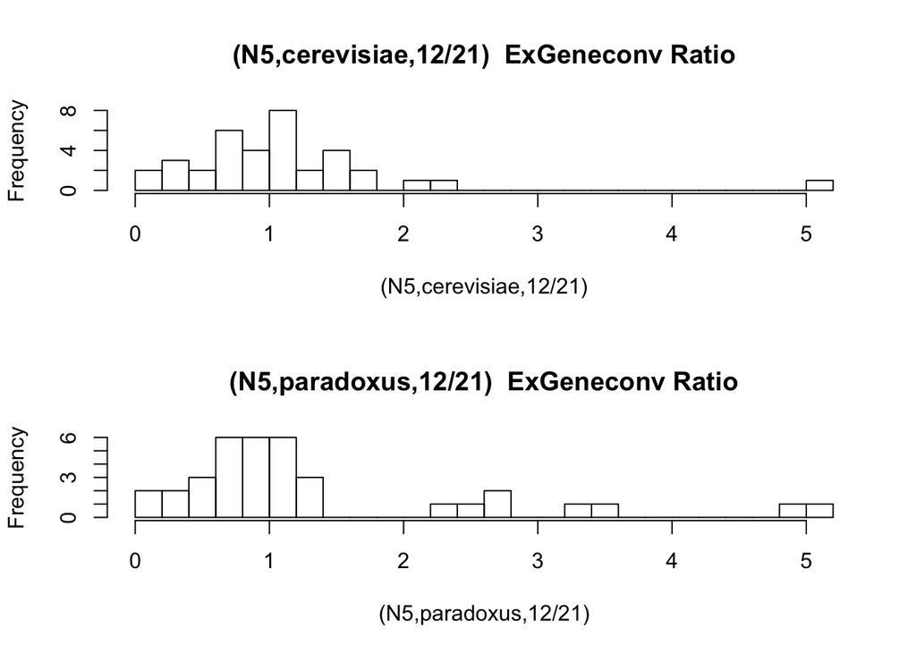

```r
par(mfrow = c(2, 1))
rows <- 35:44
for (i in rows){
  hist(HKY.nonclock.filtered[i, ], breaks = 20,
       xlab = rownames(HKY.nonclock.filtered)[i],
       main = paste(rownames(HKY.nonclock.filtered)[i], " ExGeneconv Ratio"))
}
```

HKY clock

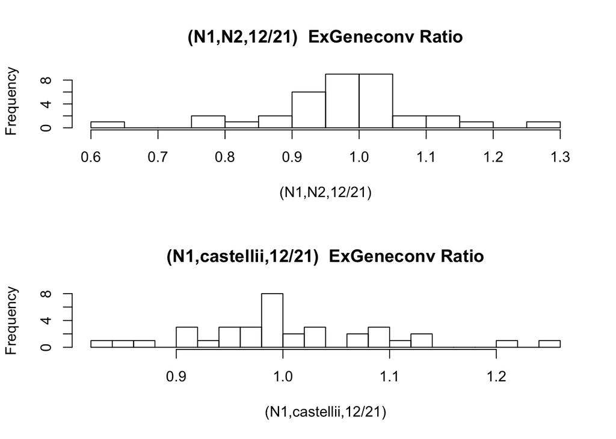

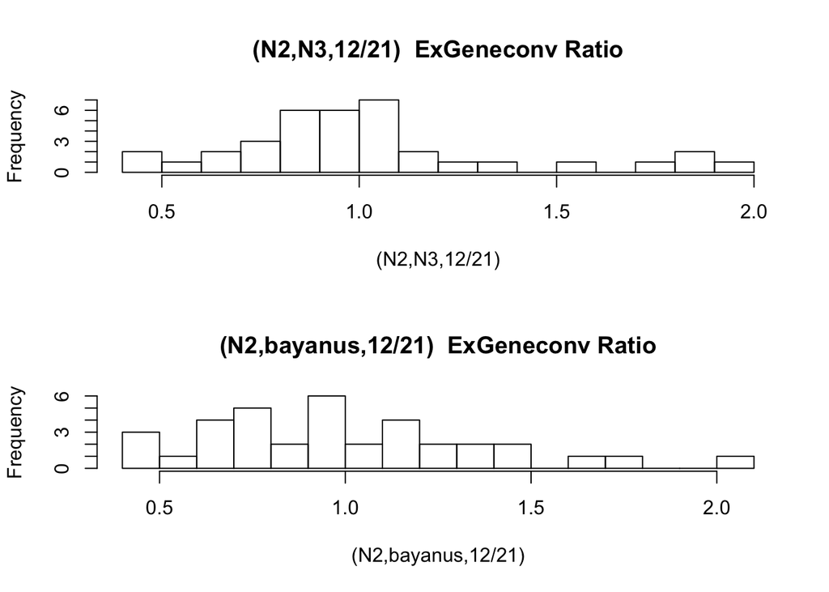

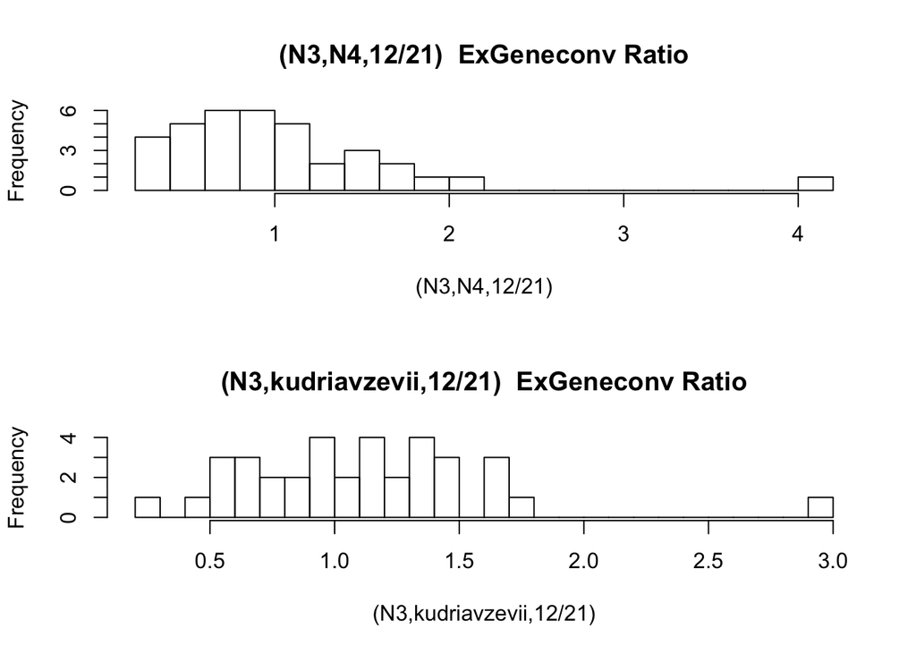

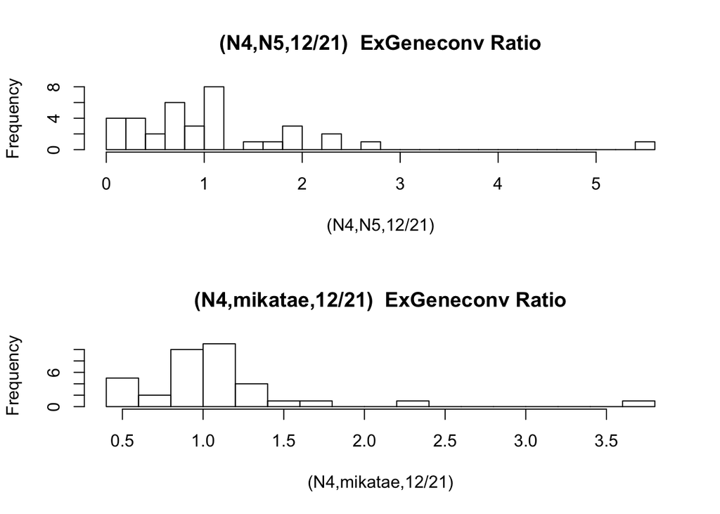

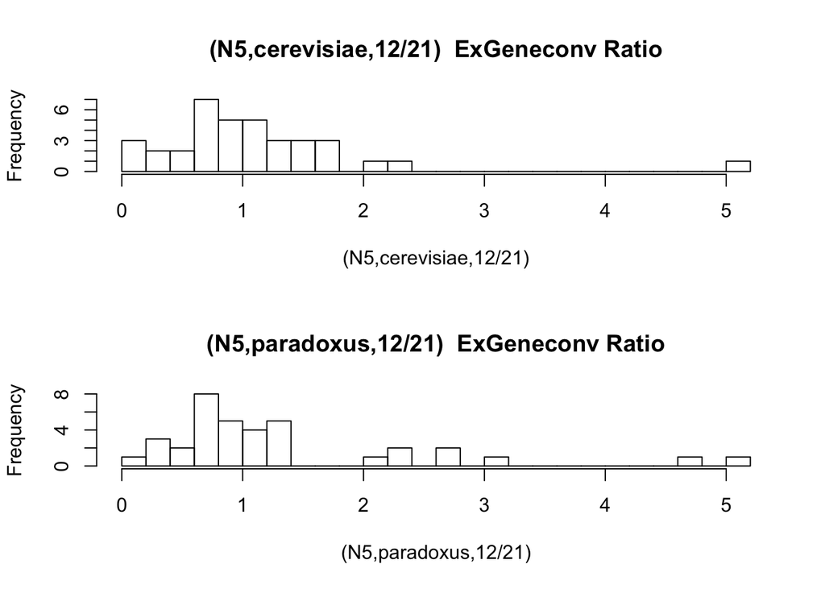

```r
par(mfrow = c(2, 1))
rows <- 35:44
for (i in rows){
  hist(HKY.clock.filtered[i, ], breaks = 20,
       xlab = rownames(HKY.clock.filtered)[i],
       main = paste(rownames(HKY.clock.filtered)[i], " ExGeneconv Ratio"))
}
```

MG94 Non-clock

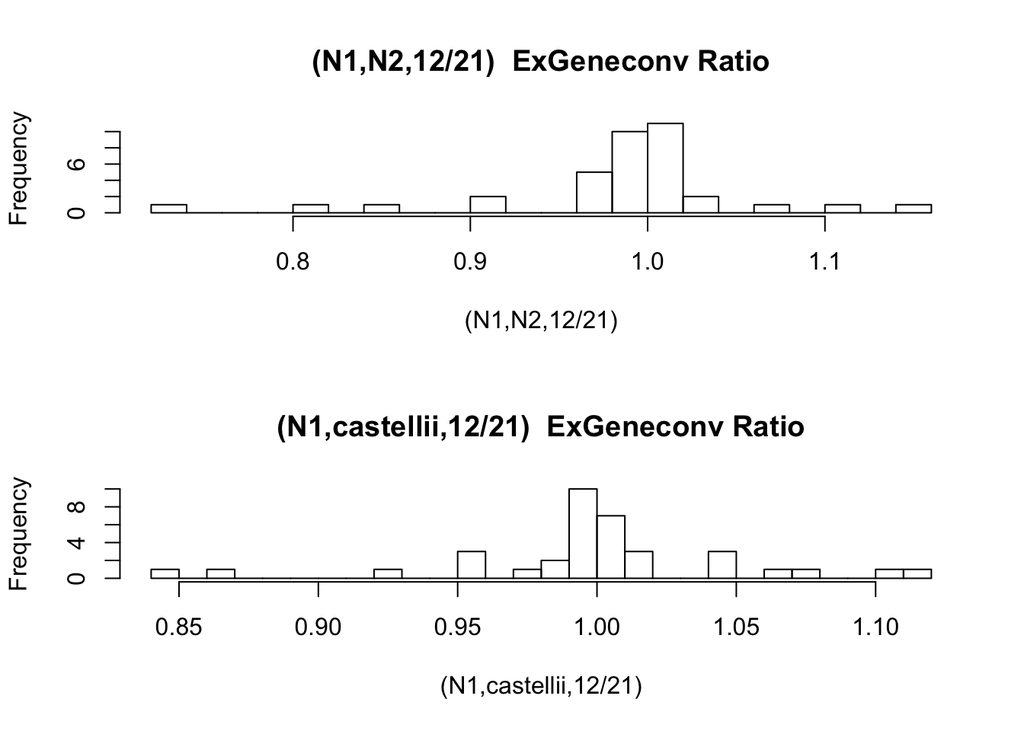

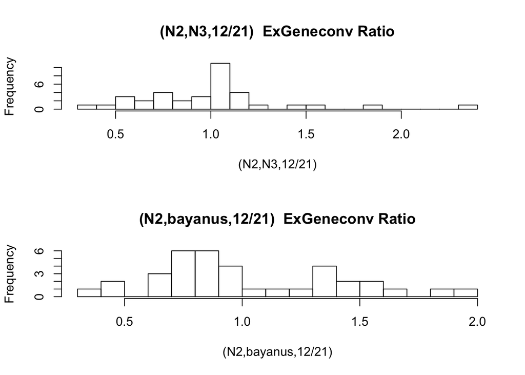

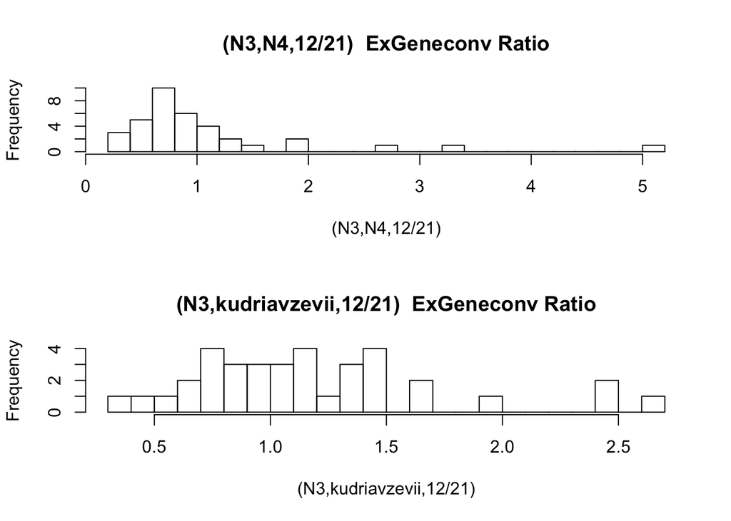

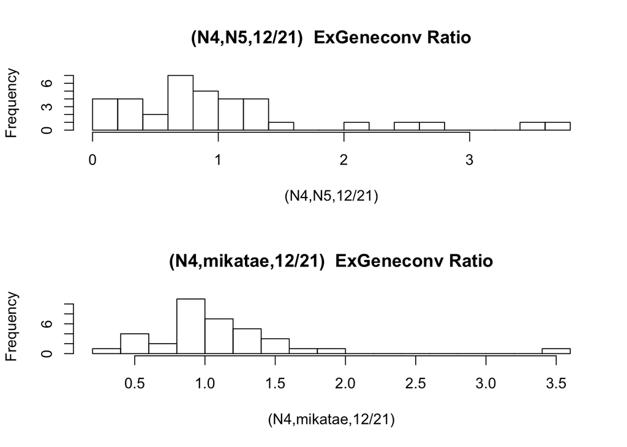

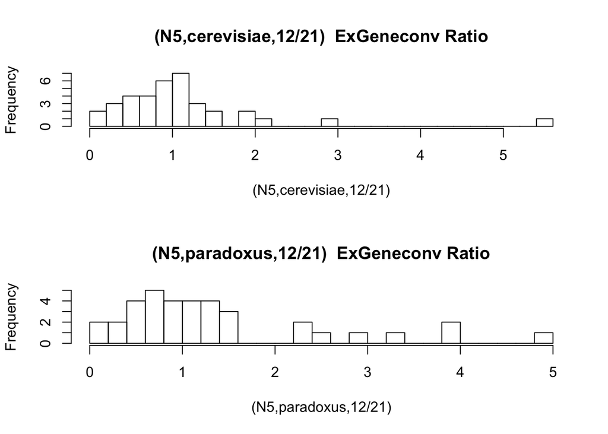

```r
par(mfrow = c(2, 1))
rows <- 36:45
for (i in rows){
  hist(MG94.nonclock.filtered[i, ], breaks = 20,
       xlab = rownames(MG94.nonclock.filtered)[i],
       main = paste(rownames(MG94.nonclock.filtered)[i], " ExGeneconv Ratio"))
}
```

MG94 clock

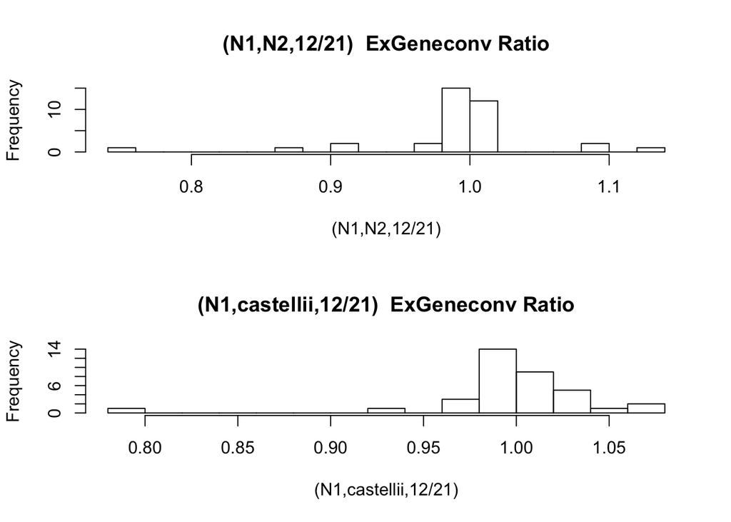

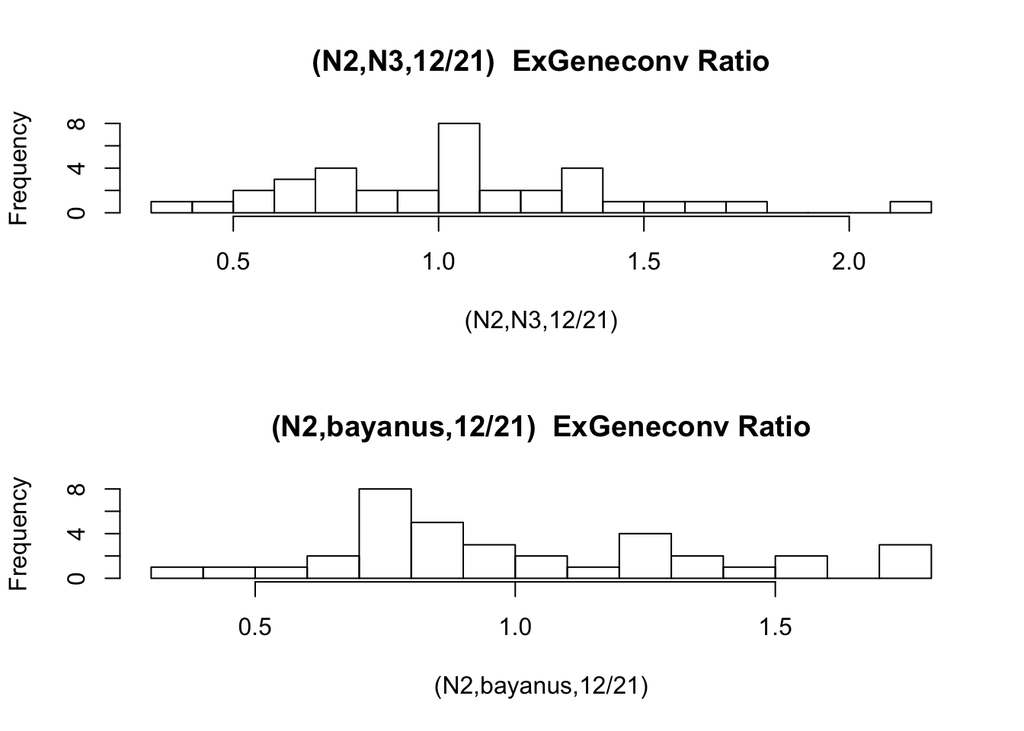

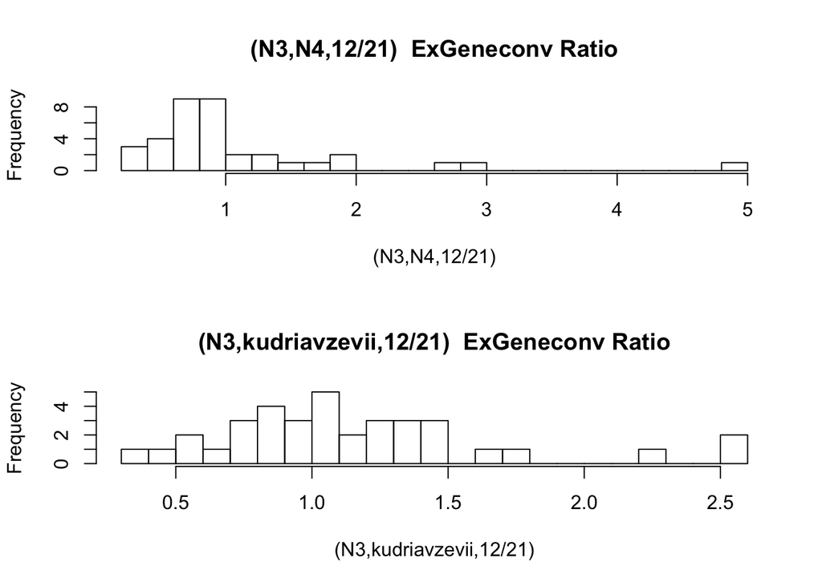

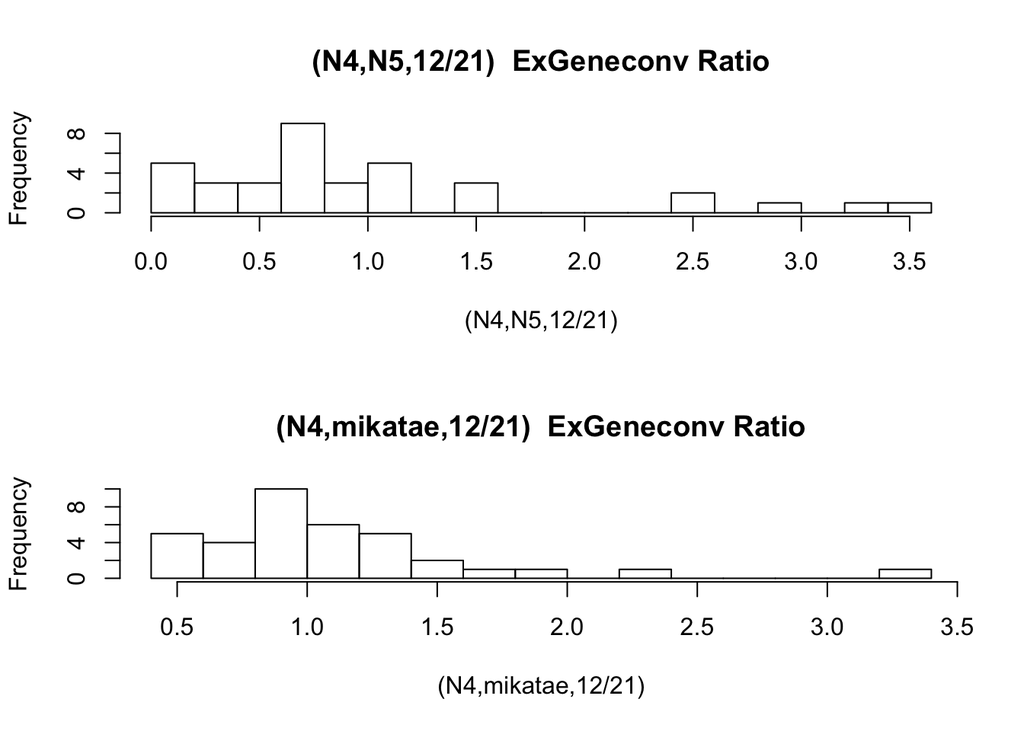

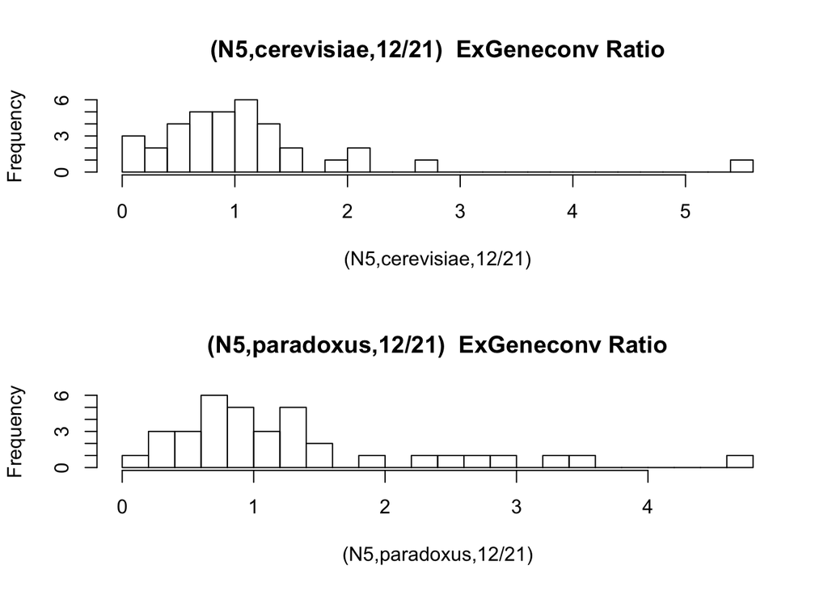

```r
par(mfrow = c(2, 1))
rows <- 36:45
for (i in rows){
  hist(MG94.clock.filtered[i, ], breaks = 20,
       xlab = rownames(MG94.clock.filtered)[i],
       main = paste(rownames(MG94.clock.filtered)[i], " ExGeneconv Ratio"))
}
```